# Analysis of Povety in America and the Implications of Race

## By Mana Gammi and Hanock Tsegaye

## Introduction

Britannica defines poverty as "the state of one who lacks a usual or socially acceptable amount of money or material possessions" causing thme to "lack the means to satisfy their basic needs" (1). While this definition is relatively vague and open to interpretation, especially in regard to what constitues as a basic need, the underlying gist is that a person who lives in poverty cannot pay for food, clean water, clothing, and shelter. While the measure of poverty varies across nations, where in its extreme it's recognized as living on less than $1.90 per day in the USA, the marker for living in poverty is not as low as you may think (2). In fact, roughly 11.6% of the US population lives in poverty (as of January 2021) -- that's 37.9 million Americans (3).

People generally associate poverty exclusively to income, but that's a tremendous misconstruction. In reality, poverty can be measured across 3 dimensions: health, education, and standard of living (2). This means when examining poverty, professionals look at child mortality rates and nutrition, school attendance, and electricity, sanitation, and housing, to give a few examples. so, poverty is not only what you can and cannot buy, but likewise an examination of the quality of one's overall human exeperience.

Poverty can be a difficult topic of study as it's not only difficult to define, but also difficult to generalize. There are many factors to consider when examining poverty rates in the USA. This includes age, gender, immigration status, familial status, ethnicity, geographical location, disability, race, and income, just to name a few examples, and it's increasingly difficult when you take into account that the aformentioned factors are not independent -- in most cases they intersect. While we recognize all the factors mentioned above are important, in this project we will only look at race,income, and location for the sake of being as thorough as we can.

The purpose of this project is to analyze poverty across America in the context of race. In other words, we're looking to see if there's a trend between poverty status and the race in which one identifies as to see if race is an indicator of poverty, but also we'll look closely at income and state in our research.

Do certain races tend to have higher poverty rates than others? On the flip side, do certain races have have lower rates than others? The goal in asking these questions and making the differentiation based on race is to indubitabily inidentify social and economic inequalities in American society. Certain members of our country endure systematic discrimination on account of their race and this keeps them from recieving the same opprotunities and having the same experiences as their counterparts. If there is indeed a correaltion between poverty and race that would mean many Americans are enduring an injustice that they'll like never be able to break away from. And because poverty is a cycle, families will be affected across generations.

Once we can recognize that these inequalities exist, and prove so beyond a shadow of a doubt, we can then take steps to rectify the error.

For the purpose of this study we recognize the following 5 groups as races: White, Black, Asian, Native Hawaiian or Pacific Islander, American Indian or Alaska Native, and we'll look at poverty statistics collected by the US government, as far back as 1959 and as recently as 2022, that record these races so that can can make direct generalizations.

We've collected tables that look at per capita income, poverty rates in regards to the total US population, poverty across states, and poverty status by race which we'll thoroughly analyze to make a confident hypothesis. We'll then use linear regression and machine learning to accept or reject this hypothesis.

This tutorial will walk you through the entire data science pipeline, which includes the following 5 stages:

1. Data Collection
2. Data Processing
3. Exploratory Analysis and Data Visualization
4. Analysis, Hypothesis Testing, and Machine Learning
5. and lastly, Insight and Policy Decision

Enjoy!

Sources:

1. Britannica, T. Editors of Encyclopaedia (2023, April 6). poverty. Encyclopedia Britannica. https://www.britannica.com/topic/poverty
2. https://www.worldvision.ca/stories/child-sponsorship/what-is-poverty
3. https://www.cnbc.com/2023/03/07/why-poverty-might-be-far-worse-in-the-us-than-its-reported.html#:~:text=As%20of%20January%202021%2C%2037.9,the%20United%20States%20Census%20Bureau

Here are the packages we'll need for the tutorial.

```python
import seaborn as sb
import requests
from bs4 import BeautifulSoup
import pandas as pd
import numpy as np
import matplotlib.pyplot as plt
from scipy import stats
import statistics
import sklearn.linear_model as slm
from sklearn.linear_model import LinearRegression
import statsmodels.api as sm
import statsmodels.formula.api as smf
import warnings
from sklearn.linear_model import Lasso
from sklearn.model_selection import train_test_split
from sklearn.metrics import mean_squared_error
warnings.filterwarnings('ignore')
```

## Data Collection, Cleaning and Processing

Our tutorial begins with collecting, processing and cleaning out data. As you can see, we've combined the first 2 stages of the data science pipeline. We've done this because collecting the data and processing it as you go is often the most organized and consistent course of action. Once you have your data, you might as well process and clean it while its right there. This prevents forgetting steps in cleaning data and data loss that can occur when switching back and forth between dataframes.

At this point you're probably wondering why to even bother cleaning data. Here are several reasons why its important:

- You can present your data in a more human readable form, which allows for easier and more accurate interpretation of data.
- It ensures data is in the correct format to be used later on.
  - For example, making sure dollars are integers or floats so we can perform calculations on them.
- It makes the data more concise because we can drop columns that are not useful and rows that are incomplete (such as because of null values).
- Going back to add changes when necessary is easier when all the code cleaning is with the table collection because everything is in one place.

The next 3 tables were collected by doing a few google searches and then downloading the tables as csv's and excel sheets. In these formats, it's quick and easy to read the data into a dataframe using pandas.

This website is incredibly helpful for the work we're doing next: https://pandas.pydata.org/pandas-docs/stable/user_guide/10min.html

### Table 1: CPS Population and Per Capita Money Income, All People: 1967 to 2021

The first table was downloaded as a CSV so we can us pandas read_csv to read it into a dataframe. The documentatio to explain how the funciton works is here : https://pandas.pydata.org/docs/reference/api/pandas.read_csv.html

```python
data1 = pd.read_csv("p01ar.csv", header=6) #header starts in row 6
print(data1.dtypes)
data1.head(7)
# this part constitues as data collection
```

```
Year                  object
Number (thousands)    object
Per capita income     object
Unnamed: 3            object
dtype: object
```

|  | Year | Number (thousands) | Per capita income | Unnamed: 3 |
| --- | --- | --- | --- | --- |
| 0 | NaN | NaN | Current\ndollars | 2021\ndollars |
| 1 | 2021 | 328,722 | 41,285 | 41,285 |
| 2 | 2020 (41) | 328,059 | 38,931 | 40,749 |
| 3 | 2019 | 325,268 | 39,156 | 41,496 |
| 4 | 2018 | 324,356 | 36,080 | 38,929 |
| 5 | 2017 (40) | 323,144 | 35,048 | 38,737 |
| 6 | 2017 | 323,156 | 34,489 | 38,119 |

Here's what the first 7 rows of the dataframe (data1) look like. Immediately, there are several issues.

- Frist, there are 2 rows of heading which makes the table confusing to read. 'Current\ndollars' and '2021\ndollars are subsets' of Per capita income. They'll need to be combined so there's only 1 row of heading and 4 columns. Then, the extra rows can be dropped. We'll use pandas rename() to rename 'Per capita income' and 'Unnamed 3:' to include 'Current\ndollars' and '2021\ndollars. Then we'll use pandas drop() to drop the first row since it doesn't hold data.
- Next, the 'Year' column has extra values in some of the rows. These values must be removed so that there's only the years represented in that column. We want this because we don't need those values for the purposes of our study and keeping them will complicate graphs we'll make later on.
- Last, using the dtypes feature of the dataframe, we can see that all the values are object. It would be better is they were all numerical -- whether as integers and floats -- so we can perform caluclations on them later. To do this, we'll first need to remove non-numerical characters from each column using pandas apply() and lambda functions. Then we can use pandas astype() function to change the columns type. Information for this function is found here: https://pandas.pydata.org/docs/reference/api/pandas.DataFrame.astype.html.

Making these changes is the beginning of the Data Processing stage for this table

```python
data1 = data1.rename(columns = {"Per capita income": "Current PCI in Dollars", "Unnamed: 3":"2021 PCI in Dollars"}) #rename headers
data1 = data1.drop(index = [0]) # now can drop the first row
data1.head(7)
#Note: PCI == Per Capita Income
```

|  | Year | Number (thousands) | Current PCI in Dollars | 2021 PCI in Dollars |
| --- | --- | --- | --- | --- |
| 1 | 2021 | 328,722 | 41,285 | 41,285 |
| 2 | 2020 (41) | 328,059 | 38,931 | 40,749 |
| 3 | 2019 | 325,268 | 39,156 | 41,496 |
| 4 | 2018 | 324,356 | 36,080 | 38,929 |
| 5 | 2017 (40) | 323,144 | 35,048 | 38,737 |
| 6 | 2017 | 323,156 | 34,489 | 38,119 |
| 7 | 2016 | 320,372 | 33,205 | 37,490 |

```python
data1['Year'] = data1['Year'].apply(lambda item : (str(item[:4])) if str.__contains__(str(item),'(') == True else item) #want to remove the numbers in paranthesis next to the years
data1['Number (thousands)'] = data1['Number (thousands)'].apply(lambda item : (item.replace(",", "") if str.__contains__(str(item),',') == True else item))
data1['Current PCI in Dollars'] = data1['Current PCI in Dollars'].apply(lambda item : (item.replace(",", "") if str.__contains__(str(item),',') == True else item))
data1['2021 PCI in Dollars'] = data1['2021 PCI in Dollars'].apply(lambda item : (item.replace(",", "") if str.__contains__(str(item),',') == True else item))
data1 = data1.astype({'Number (thousands)': int, 'Current PCI in Dollars': int, '2021 PCI in Dollars':int, 'Year': int})
print(data1.dtypes)
data1.head(10)
```

```
Year                      int32
Number (thousands)        int32
Current PCI in Dollars    int32
2021 PCI in Dollars       int32
dtype: object
```

|  | Year | Number (thousands) | Current PCI in Dollars | 2021 PCI in Dollars |
| --- | --- | --- | --- | --- |
| 1 | 2021 | 328722 | 41285 | 41285 |
| 2 | 2020 | 328059 | 38931 | 40749 |
| 3 | 2019 | 325268 | 39156 | 41496 |
| 4 | 2018 | 324356 | 36080 | 38929 |
| 5 | 2017 | 323144 | 35048 | 38737 |
| 6 | 2017 | 323156 | 34489 | 38119 |
| 7 | 2016 | 320372 | 33205 | 37490 |
| 8 | 2015 | 318868 | 31653 | 36198 |
| 9 | 2014 | 316168 | 30176 | 34569 |
| 10 | 2013 | 313443 | 30027 | 34980 |

Notice: changes need to be reassigned to the dataframe, otherwise the change will be lost!

In the segment above, we had to remove ',' from the last 3 columns so that they could be turned into ints.

### Table 2: People in Poverty by Nativity: 1993 to 2021

This table was downloaded as a excel sheet, so we can read it in using panda's read_excel. Documentatio for this function can be found here: https://pandas.pydata.org/docs/reference/api/pandas.read_excel.html.

```python
data2 = pd.read_excel("hstpov16.xlsx", header = 3) #note: 2 levels of headers
data2.head()
```

|  | Year | All people | Unnamed: 2 | Unnamed: 3 | Native | Unnamed: 5 | Unnamed: 6 | Foreign-born | Unnamed: 8 | Unnamed: 9 | Unnamed: 10 | Unnamed: 11 | Unnamed: 12 | Unnamed: 13 | Unnamed: 14 | Unnamed: 15 |
| --- | --- | --- | --- | --- | --- | --- | --- | --- | --- | --- | --- | --- | --- | --- | --- | --- |
| 0 | NaN | NaN | NaN | NaN | NaN | NaN | NaN | Total | NaN | NaN | Naturalized citizen | NaN | NaN | Not a citizen | NaN | NaN |
| 1 | NaN | Total | Number in poverty | Percent in poverty | Total | Number in poverty | Percent in poverty | Total | Number in poverty | Percent in poverty | Total | Number in poverty | Percent in poverty | Total | Number in poverty | Percent in poverty |
| 2 | 2021 | 328191 | 37933 | 11.6 | 281383 | 31083 | 11 | 46808 | 6850 | 14.6 | 22874 | 2428 | 10.6 | 23934 | 4422 | 18.5 |
| 3 | 2020 (1) | 327570 | 37548 | 11.5 | 282408 | 31485 | 11.1 | 45162 | 6063 | 13.4 | 22800 | 2087 | 9.2 | 22362 | 3977 | 17.8 |
| 4 | 2019 | 324754 | 33984 | 10.5 | 279867 | 28342 | 10.1 | 44886 | 5643 | 12.6 | 22746 | 2038 | 9 | 22140 | 3605 | 16.3 |

This is dataframe is extremely confusing to look at because of the way the information was organzied. The current header distinguished by people groups, the first row distinguished by citizenship, and the next row labels what information is held in that column.

We're going to do several things.

```python
#just want Native groups
dataNew = data2.loc[:32, ["Year","Native","Unnamed: 5", "Unnamed: 6"]]
dataNew['Year'] = dataNew['Year'].apply(lambda item : (str(item[:4])) if str.__contains__(str(item),'(') == True else item)
#want to remove the numbers in paranthesis next to the years
dataNew = dataNew.rename(columns = {"Native": "Total", "Unnamed: 5":"Number in Poverty", "Unnamed: 6": "Percent in Poverty"}) #rename headers
dataNew = dataNew.drop(index = [0,1])
print(dataNew.dtypes)
dataNew.head(10)
```

```
Year                  object
Total                 object
Number in Poverty     object
Percent in Poverty    object
dtype: object
```

|  | Year | Total | Number in Poverty | Percent in Poverty |
| --- | --- | --- | --- | --- |
| 2 | 2021 | 281383 | 31083 | 11 |
| 3 | 2020 | 282408 | 31485 | 11.1 |
| 4 | 2019 | 279867 | 28342 | 10.1 |
| 5 | 2018 | 278051 | 31828 | 11.4 |
| 6 | 2017 | 277131 | 33143 | 12 |
| 7 | 2017 | 277158 | 33095 | 11.9 |
| 8 | 2016 | 276089 | 33999 | 12.3 |
| 9 | 2015 | 275398 | 35973 | 13.1 |
| 10 | 2014 | 273628 | 38871 | 14.2 |
| 11 | 2013 | 272423 | 38831 | 14.3 |

Here, we've printed the data types of the remaining columns and once again, they're all objects. Lets change them once again to numerical types so we can perform calculations on them later.

```python
dataNew = dataNew.astype({'Year':'int', 'Total':int, 'Number in Poverty':int, 'Percent in Poverty':float})
print(dataNew.dtypes)
```

```
Year                    int32
Total                   int32
Number in Poverty       int32
Percent in Poverty    float64
dtype: object
```

### Table 3: Poverty Status of People by Family Relationship, Race, and Hispanic Origin: 1959 to 2021

This table was downloaded as an excel sheet, so we can read it in using panda's read_excel. You can look at the same link above.

```python
data3 = pd.read_excel("hstpov2 .xlsx", header = 4 ) #several headers, first one starts on line 4
print(data3.dtypes)
data3.head()
# Note, population is in thousands!
```

```
Year                     object
All people               object
Unnamed: 2               object
Unnamed: 3               object
People in families       object
Unnamed: 5               object
Unnamed: 6               object
Unnamed: 7               object
Unnamed: 8               object
Unnamed: 9               object
Unrelated individuals    object
Unnamed: 11              object
Unnamed: 12              object
dtype: object
```

|  | Year | All people | Unnamed: 2 | Unnamed: 3 | People in families | Unnamed: 5 | Unnamed: 6 | Unnamed: 7 | Unnamed: 8 | Unnamed: 9 | Unrelated individuals | Unnamed: 11 | Unnamed: 12 |
| --- | --- | --- | --- | --- | --- | --- | --- | --- | --- | --- | --- | --- | --- |
| 0 | NaN | NaN | NaN | NaN | All families | NaN | NaN | Families with female householder, no spouse pr... | NaN | NaN | NaN | NaN | NaN |
| 1 | NaN | Total | Below poverty | NaN | Total | Below poverty | NaN | Total | Below poverty | NaN | Total | Below poverty | NaN |
| 2 | NaN | NaN | Number | Percent | NaN | Number | Percent | NaN | Number | Percent | NaN | Number | Percent |
| 3 | 2021 | 328191 | 37933 | 11.6 | 263764 | 25077 | 9.5 | 48476 | 12264 | 25.3 | 63398 | 12513 | 19.7 |
| 4 | 2020 (1) | 327570 | 37548 | 11.5 | 264437 | 25232 | 9.5 | 48984 | 12469 | 25.5 | 62097 | 11963 | 19.3 |

This table is a mess so we're going to do several things and in this order.

1. Rename columns so they're indicative of the informaiton they hold. Like the previous tables, it looks like the headers are multiple rows so we need to look at the first few rows. We're going to use the same pandas rename() funciton.
2. Drop columns we dont need. We're not distinguishing by family status, so we'll remove the columns pertaining to that. We'll again pandas drop() again.
3. Create new dataframes so that the information can be seperated by race. You cant tell from the table above, but the excel_sheet we downloaded is composed of several tables. So by using indices and pandas iloc, we can take slices of the dataframe and make a new dataframe out if it.

```python
data3 = data3.rename(columns = {"All people" : "Total Number", "Unnamed: 2": "Number Below Poverty",
                                "Unnamed: 3": "Percent Below Poverty", "Unnamed: 7":"Female HoH", "Unnamed: 9": "Percent Female HoH Below Poverty"})
data3 = data3.loc[:, ["Year", "Total Number","Number Below Poverty","Percent Below Poverty", "Female HoH", "Percent Female HoH Below Poverty"]]
data3['Year'] = data3['Year'].apply(lambda item : (str(item[:4])) if str.__contains__(str(item),'(') == True else item) #want to remove the numbers in paranthesis next to the years


data3.head()

# not gonna drop first few rows bc affects rest of new dataframes with indices
```

|  | Year | Total Number | Number Below Poverty | Percent Below Poverty | Female HoH | Percent Female HoH Below Poverty |
| --- | --- | --- | --- | --- | --- | --- |
| 0 | NaN | NaN | NaN | NaN | Families with female householder, no spouse pr... | NaN |
| 1 | NaN | Total | Below poverty | NaN | Total | NaN |
| 2 | NaN | NaN | Number | Percent | NaN | Percent |
| 3 | 2021 | 328191 | 37933 | 11.6 | 48476 | 25.3 |
| 4 | 2020 | 327570 | 37548 | 11.5 | 48984 | 25.5 |

Important note: we're not dropping any rows because we're going to 'slice' the dataframe anyway and this would throw off indices we're going to use.

Next, the first table in the dataframe holds information across all races. We're going to extract just that table and save it in a new dataframe.

```python
#splitting up data into different tables for each race
dataAllRaces= data3.iloc[3:68,:]
dataAllRaces
```

|  | Year | Total Number | Number Below Poverty | Percent Below Poverty | Female HoH | Percent Female HoH Below Poverty |
| --- | --- | --- | --- | --- | --- | --- |
| 3 | 2021 | 328191 | 37933 | 11.6 | 48476 | 25.3 |
| 4 | 2020 | 327570 | 37548 | 11.5 | 48984 | 25.5 |
| 5 | 2019 | 324754 | 33984 | 10.5 | 46255 | 24.3 |
| 6 | 2018 | 323847 | 38146 | 11.8 | 46660 | 26.8 |
| 7 | 2017 | 322548 | 39564 | 12.3 | 47517 | 28.5 |
| ... | ... | ... | ... | ... | ... | ... |
| 63 | 1963 | 187258 | 36436 | 19.5 | N | 47.7 |
| 64 | 1962 | 184276 | 38625 | 21 | N | 50.3 |
| 65 | 1961 | 181277 | 39628 | 21.9 | N | 48.1 |
| 66 | 1960 | 179503 | 39851 | 22.2 | N | 48.9 |
| 67 | 1959 | 176557 | 39490 | 22.4 | N | 49.4 |

65 rows × 6 columns

Now we're going to do the same for each race. We'll extract the correct rows by looking at the indices of the excel sheet and then save them in a new dataframe. We actually will not end up using it as we already have a table that provides the same info.

For these dataframes, we'll also make a new column called 'Race' and add the correct race for each dataframe. After, we'll drop rows that are empty using dropna().

```python
dataWhite = data3.iloc[73:143,:]
dataWhite['Race'] = 'White'
dataWhite= dataWhite.dropna()
dataWhite.head()
```

|  | Year | Total Number | Number Below Poverty | Percent Below Poverty | Female HoH | Percent Female HoH Below Poverty | Race |
| --- | --- | --- | --- | --- | --- | --- | --- |
| 73 | 2021 | 248909 | 24919 | 10 | 28961 | 22.7 | White |
| 74 | 2020 | 249083 | 25183 | 10.1 | 29829 | 23.4 | White |
| 75 | 2019 | 248086 | 22512 | 9.1 | 27848 | 21.6 | White |
| 76 | 2018 | 247634 | 24945 | 10.1 | 28375 | 24.6 | White |
| 77 | 2017 | 247255 | 26026 | 10.5 | 28671 | 25.8 | White |

```python
dataBlack = data3.iloc[236:300,:]
dataBlack['Race'] = 'Black'
dataBlack = dataBlack.dropna()
dataBlack.head()
```

|  | Year | Total Number | Number Below Poverty | Percent Below Poverty | Female HoH | Percent Female HoH Below Poverty | Race |
| --- | --- | --- | --- | --- | --- | --- | --- |
| 236 | 2021 | 43976 | 8583 | 19.5 | 14035 | 30.8 | Black |
| 237 | 2020 | 43694 | 8556 | 19.6 | 14082 | 29.9 | Black |
| 238 | 2019 | 42965 | 8073 | 18.8 | 13939 | 29.5 | Black |
| 239 | 2018 | 42773 | 8884 | 20.8 | 13500 | 31.7 | Black |
| 240 | 2017 | 42477 | 9224 | 21.7 | 13986 | 34.4 | Black |

```python
dataAsian= data3.iloc[332:374,:]
dataAsian['Race'] = 'Asian/Pacific Islander'
dataAsian = dataAsian.dropna()
dataAsian.head()
```

|  | Year | Total Number | Number Below Poverty | Percent Below Poverty | Female HoH | Percent Female HoH Below Poverty | Race |
| --- | --- | --- | --- | --- | --- | --- | --- |
| 332 | 2021 | 20676 | 1922 | 9.3 | 1989 | 15.1 | Asian/Pacific Islander |
| 333 | 2020 | 20352 | 1645 | 8.1 | 1783 | 17.4 | Asian/Pacific Islander |
| 334 | 2019 | 19926 | 1464 | 7.3 | 1576 | 16.1 | Asian/Pacific Islander |
| 335 | 2018 | 19768 | 1996 | 10.1 | 1686 | 19.4 | Asian/Pacific Islander |
| 336 | 2017 | 19526 | 1891 | 9.7 | 1715 | 16.8 | Asian/Pacific Islander |

```python
dataNA= data3.iloc[406:448,:]
dataNA['Race'] = 'American Indian/AN' #Native American, Alaska Native
dataNA = dataNA.dropna()
dataNA.head()
```

|  | Year | Total Number | Number Below Poverty | Percent Below Poverty | Female HoH | Percent Female HoH Below Poverty | Race |
| --- | --- | --- | --- | --- | --- | --- | --- |
| 406 | 2021 | 4109 | 998 | 24.3 | 999 | 43.5 | American Indian/AN |
| 407 | 2020 | 3950 | 791 | 20 | 877 | 34.6 | American Indian/AN |
| 408 | 2019 | 3735 | 677 | 18.1 | 701 | 33 | American Indian/AN |
| 409 | 2018 | 3663 | 808 | 22.1 | 828 | 28.1 | American Indian/AN |
| 410 | 2017 | 3616 | 790 | 21.8 | 888 | 33.7 | American Indian/AN |

```python
dataHispanic = data3.iloc[480:532,:]
dataHispanic['Race'] = 'Hispanic'
dataHispanic = dataHispanic.dropna()
dataHispanic.head()
```

|  | Year | Total Number | Number Below Poverty | Percent Below Poverty | Female HoH | Percent Female HoH Below Poverty | Race |
| --- | --- | --- | --- | --- | --- | --- | --- |
| 480 | 2021 | 62482 | 10690 | 17.1 | 12382 | 30.3 | Hispanic |
| 481 | 2020 | 61769 | 10520 | 17 | 12856 | 30.1 | Hispanic |
| 482 | 2019 | 60602 | 9545 | 15.7 | 12248 | 28.7 | Hispanic |
| 483 | 2018 | 59957 | 10526 | 17.6 | 11939 | 31.1 | Hispanic |
| 484 | 2017 | 59051 | 10816 | 18.3 | 12155 | 35.2 | Hispanic |

Hispanic is not technically a race but we'll take note of it.

Now, we're going to add all the dataframes together by using pandas concat() to basically stack all the dataframes. We want this because having all the data in one table makes it easier to use.

We're also going to change column types so graphing later on is easier.

```python
# combining all the DFs
finalDF = pd.concat([ dataHispanic ,dataWhite , dataAsian , dataBlack, dataNA], ignore_index=True, axis=0)
finalDF['Percent Below Poverty'] = finalDF['Percent Below Poverty'].apply(lambda item: float(item))
finalDF['Percent Female HoH Below Poverty'] = finalDF['Percent Female HoH Below Poverty'].astype(float)
finalDF['Percent Female HoH'] = (finalDF['Female HoH'].astype(int) / finalDF['Total Number']) * 100
finalDF= finalDF.astype({'Year':'int', 'Total Number':int, 'Number Below Poverty':int, 'Percent Below Poverty':float})

finalDF
```

|  | Year | Total Number | Number Below Poverty | Percent Below Poverty | Female HoH | Percent Female HoH Below Poverty | Race | Percent Female HoH |
| --- | --- | --- | --- | --- | --- | --- | --- | --- |
| 0 | 2021 | 62482 | 10690 | 17.1 | 12382 | 30.3 | Hispanic | 19.816907 |
| 1 | 2020 | 61769 | 10520 | 17.0 | 12856 | 30.1 | Hispanic | 20.813029 |
| 2 | 2019 | 60602 | 9545 | 15.7 | 12248 | 28.7 | Hispanic | 20.210554 |
| 3 | 2018 | 59957 | 10526 | 17.6 | 11939 | 31.1 | Hispanic | 19.912604 |
| 4 | 2017 | 59051 | 10816 | 18.3 | 12155 | 35.2 | Hispanic | 20.583902 |
| ... | ... | ... | ... | ... | ... | ... | ... | ... |
| 235 | 1991 | 1793 | 562 | 31.3 | 347 | 59.6 | American Indian/AN | 19.35304 |
| 236 | 1990 | 1560 | 444 | 28.5 | 334 | 54.1 | American Indian/AN | 21.410256 |
| 237 | 1989 | 1445 | 345 | 23.9 | 269 | 56.5 | American Indian/AN | 18.615917 |
| 238 | 1988 | 1454 | 440 | 30.2 | 269 | 42.9 | American Indian/AN | 18.500688 |
| 239 | 1987 | 1345 | 387 | 28.8 | 325 | 48.4 | American Indian/AN | 24.163569 |

240 rows × 8 columns

Now all the data is together and has a column that'll allow us to track race and poverty across years.

### Table 4: Poverty Rate by Race and Ethnicity

This table was also downloaded as a CSV, so we can again use pandas read_csv

```python
povByRace = pd.read_csv("povRace.csv", header=2)
povByRace.head(20)
```

|  | Location | White | Black | Hispanic | Asian/Native Hawaiian and Pacific Islander | American Indian/Alaska Native | Multiple Races | Total | Footnotes |
| --- | --- | --- | --- | --- | --- | --- | --- | --- | --- |
| 0 | United States | 0.095 | 0.217 | 0.176 | 0.102 | 0.259 | 0.141 | 0.128 | 1.0 |
| 1 | Alabama | 0.119 | 0.247 | 0.244 | 0.114 | 0.144 | 0.184 | 0.160 | NaN |
| 2 | Alaska | 0.078 | 0.251 | 0.130 | NaN | 0.206 | 0.124 | 0.110 | NaN |
| 3 | Arizona | 0.089 | 0.168 | 0.171 | 0.111 | 0.348 | 0.105 | 0.129 | NaN |
| 4 | Arkansas | 0.137 | 0.272 | 0.218 | 0.116 | 0.117 | 0.157 | 0.164 | NaN |
| 5 | California | 0.090 | 0.194 | 0.152 | 0.101 | 0.225 | 0.117 | 0.123 | NaN |
| 6 | Colorado | 0.077 | 0.177 | 0.148 | 0.082 | 0.156 | 0.116 | 0.099 | NaN |
| 7 | Connecticut | 0.068 | 0.145 | 0.196 | 0.080 | NaN | 0.101 | 0.101 | NaN |
| 8 | Delaware | 0.073 | 0.170 | 0.202 | 0.072 | NaN | 0.180 | 0.112 | NaN |
| 9 | District of Columbia | 0.050 | 0.280 | 0.090 | 0.174 | NaN | 0.158 | 0.165 | NaN |
| 10 | Florida | 0.100 | 0.202 | 0.157 | 0.098 | 0.215 | 0.137 | 0.131 | NaN |
| 11 | Georgia | 0.095 | 0.203 | 0.197 | 0.090 | 0.270 | 0.152 | 0.141 | NaN |
| 12 | Hawaii | 0.118 | 0.257 | 0.135 | 0.096 | NaN | 0.125 | 0.113 | NaN |
| 13 | Idaho | 0.101 | NaN | 0.139 | 0.143 | 0.173 | 0.153 | 0.112 | NaN |
| 14 | Illinois | 0.085 | 0.243 | 0.143 | 0.104 | 0.284 | 0.140 | 0.120 | NaN |
| 15 | Indiana | 0.101 | 0.204 | 0.185 | 0.170 | NaN | 0.167 | 0.121 | NaN |
| 16 | Iowa | 0.094 | 0.312 | 0.172 | 0.139 | 0.411 | 0.146 | 0.111 | NaN |
| 17 | Kansas | 0.096 | 0.277 | 0.180 | 0.099 | NaN | 0.177 | 0.120 | NaN |
| 18 | Kentucky | 0.153 | 0.248 | 0.261 | 0.096 | 0.424 | 0.194 | 0.165 | NaN |
| 19 | Louisiana | 0.123 | 0.321 | 0.208 | 0.188 | 0.262 | 0.262 | 0.196 | NaN |

Here we can see that the 'Footnotes` column is totally empty, so lets remove that.

But more complicatedly, there a empty values across other rows and columns -- for now we'll leave them as is. We take care of this later on.

```python
povByRace = povByRace.drop(columns = {"Footnotes"}) #dont need
povByRace.head()
```

|  | Location | White | Black | Hispanic | Asian/Native Hawaiian and Pacific Islander | American Indian/Alaska Native | Multiple Races | Total |
| --- | --- | --- | --- | --- | --- | --- | --- | --- |
| 0 | United States | 0.095 | 0.217 | 0.176 | 0.102 | 0.259 | 0.141 | 0.128 |
| 1 | Alabama | 0.119 | 0.247 | 0.244 | 0.114 | 0.144 | 0.184 | 0.160 |
| 2 | Alaska | 0.078 | 0.251 | 0.130 | NaN | 0.206 | 0.124 | 0.110 |
| 3 | Arizona | 0.089 | 0.168 | 0.171 | 0.111 | 0.348 | 0.105 | 0.129 |
| 4 | Arkansas | 0.137 | 0.272 | 0.218 | 0.116 | 0.117 | 0.157 | 0.164 |

```python
print(povByRace.dtypes)
# want to double check the datatypes of each column are appropriate for the data they hold so they can be best used later
```

```
Location                                       object
White                                         float64
Black                                         float64
Hispanic                                      float64
Asian/Native Hawaiian and Pacific Islander    float64
American Indian/Alaska Native                 float64
Multiple Races                                float64
Total                                         float64
dtype: object
```

These types are acceptable

### Table 5 : Median Household Income by Race

This next table we're going to perform webscrapping to obtain. Here's how the process works:

1. store the URL of the webpage that stores the desired table.
2. Use pythons requests packages get() function to send a GET request to the specified url. Here's a website that explains how the function works well : https://www.w3schools.com/python/ref_requests_get.asp.
3. Use pythons BeautifulSoup package to parse the website. Then we can use prettify() the read through the webpage's html code and see where our table begins. We've commented it out as the result is very long and tedious to scroll through.
4. use findall() to get the table and then read_html to read the table into a dataframe. Notice the result of read_html is an array -- we want the first element.

Here's a webpage that has examples of the entire process : https://www.geeksforgeeks.org/implementing-web-scraping-python-beautiful-soup/.

```python
url = 'https://www.pgpf.org/blog/2023/02/income-and-wealth-in-the-united-states-an-overview-of-recent-data'

medByRace = requests.get(url)

soup1 = BeautifulSoup(medByRace.content, 'html.parser')
# print(soup1.prettify())

table1 = soup1.findAll('table') #returns an array of tall the instances of 'table' in the webpage
tables = pd.read_html(str(table1))
df = tables[2] #the third table on the webpage is the one we want
print(df.dtypes)
df
```

```
Race/Ethnicity of Household Head               object
2020 Median Household Income (2021 dollars)    object
2021 Median Household Income                   object
dtype: object
```

|  | Race/Ethnicity of Household Head | 2020 Median Household Income (2021 dollars) | 2021 Median Household Income |
| --- | --- | --- | --- |
| 0 | All races/ethnicities | $71,186 | $70,784 |
| 1 | Asian | $99,622 | $101,418 |
| 2 | White, not Hispanic | $78,912 | $77,999 |
| 3 | Hispanic (any race) | $58,015 | $57,981 |
| 4 | Black | $48,175 | $48,297 |

```python
df['2020 Median Household Income (2021 dollars)'] = df['2020 Median Household Income (2021 dollars)'].apply(lambda x: x[1:].replace(",",'')).astype(float)
df['2021 Median Household Income'] = df['2021 Median Household Income'].apply(lambda x: x[1:].replace(",",'')).astype(float)
df.head()
```

|  | Race/Ethnicity of Household Head | 2020 Median Household Income (2021 dollars) | 2021 Median Household Income |
| --- | --- | --- | --- |
| 0 | All races/ethnicities | 71186.0 | 70784.0 |
| 1 | Asian | 99622.0 | 101418.0 |
| 2 | White, not Hispanic | 78912.0 | 77999.0 |
| 3 | Hispanic (any race) | 58015.0 | 57981.0 |
| 4 | Black | 48175.0 | 48297.0 |

## Exploratory Analysis and Data Visualization

Now that the data is clean and human readable, we can try to analyze and visualize it. This will help us detect patterns and trends that'll make way for generalizations.

### Poverty and Time

First, we're going to plot 'Percent in Poverty' vs 'Year' using matplot libs scatter(). Documentation for this function can be found here: https://matplotlib.org/stable/api/_as_gen/matplotlib.pyplot.scatter.html.

We're doing this to see if there's a trend between time and poverty, meaning, how has poverty changed in the last few decades?

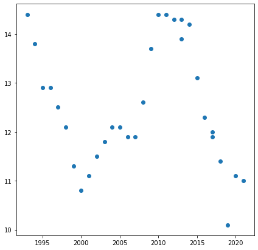

```python
fig, ax = plt.subplots(figsize=(7, 7))
plt.scatter( x= dataNew['Year'], y =dataNew['Percent in Poverty'])
```

The results of our scatter plot show that Poverty vs Year does not a have a linear, positive relationship as we had expected. This means that there is not a constant rate of change between time and poverty and we cannot create a linear regression of the relationship

It's likely that world events are a major contributor to the fluctuations in poverty. For example, just before 2010 you see the beginning of an increase inpoverty rates that contines another 5 years. This corresponsd to the 2008 recession that would likely have been a monumental trigger for poverty.

### Poverty and Race

For our next plot we're going to try get a visual of race in regards to poverty.

When creating the graph, 'Race' is the independent variable and 'Perent Below Poverty' is the dependet variable. Aka Percent Below Poverty Vs. Race

For better visualization they are distinguishable by color, which was done using a dictionary that stored race (key) and colors (value).

The make the table, we first used pandas groupby() to make groups by race. Then we iterated through these groups to print the rows according to their key (race) so that they have the right color.

We used matplotlib plot() to make a scatter plot of the data. Documentation can be found here: https://matplotlib.org/stable/api/_as_gen/matplotlib.pyplot.plot.html.

x is set to 'Race' and y to 'Percent Below Poverty'.

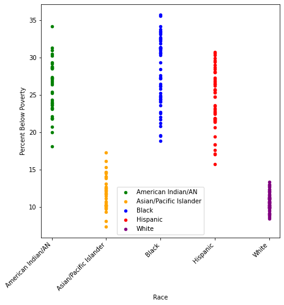

```python
colors = {"American Indian/AN" : "green", "Hispanic" : "red", "Black" : "blue", "White": "purple" , "Asian/Pacific Islander" : "orange"}

fig, ax = plt.subplots(figsize=(7, 7))
groupedDF = finalDF.groupby(['Race'])
for key, group in groupedDF :
        group.plot(ax = ax, kind='scatter', y='Percent Below Poverty', x='Race', label=key,color=colors[key])

plt.xticks(rotation=45, ha='right') #so that the x-axis labels dont merge
plt.xlabel('Race')
plt.ylabel('Percent Below Poverty')
plt.show()
```

Here, you can see that certain races have higher 'Percent Below Poverty' points than others and in higher numbers. In other words, certain races have higher poverty rates and in higher amounts. Thus, a relationship does exist between poverty and race.

#### Poverty, Race, and Time

Next, we're going to make a plot that shows Percent Below Poverty vs. Year, but we'll keep our color coding so we can distinguish by race.

To do this, we kept our grouping from the previous plot, but made a new plot and changed 'x' to 'Year'.

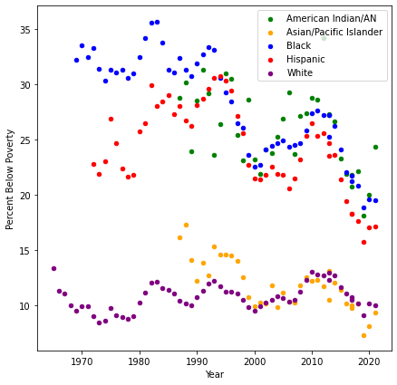

```python
fig, ax = plt.subplots(figsize=(7, 7))
for key, group in groupedDF :
        group.plot(ax = ax, kind='scatter', y='Percent Below Poverty', x='Year', label=key,color=colors[key])

plt.xlabel('Year')
plt.ylabel('Percent Below Poverty')
plt.show()
```

To see what the trend would look like for each race, we'll use sklearns linear regression function to plot a fitted line for each race. Documentation for the function can be found here: https://scikit-learn.org/stable/modules/generated/sklearn.linear_model.LinearRegression.html.

Here's the process we'll utilize:

1. Create a dataframe that will group the data by race using pandas groupby().
2. Iterate through the the dataframe rows by group.
3. For each group fit a linear regression with 'Year' as the x-axis and 'Percent Below Poverty' as the y.
4. Plot the predicted regression for each group.

We've printed out the coefficient and intercept of each fitted line just in case it'll be handy later on.

The following graph illustrates that despite the decrease in pverty generally over time, generally, Hispanic, Black, and Native American people are more likely to experiecne poverty. The lines also are prediction lines that illustrate predicted percentage below poverty every year based on their race.

```
American Indian/AN:[343.4226586],[[-0.15840149]]
Asian/Pacific Islander:[336.60689782],[[-0.16201369]]
Black:[525.74970826],[[-0.24937306]]
Hispanic:[296.99674322],[[-0.13658207]]
White:[-33.33509618],[[0.02210022]]
```

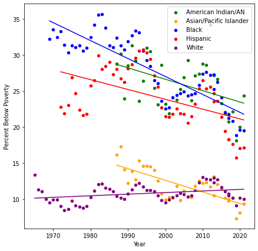

```
   Year  Total Number  Number Below Poverty  Percent Below Poverty Female HoH  \
0  2021         62482                 10690                   17.1      12382
1  2020         61769                 10520                   17.0      12856
2  2019         60602                  9545                   15.7      12248
3  2018         59957                 10526                   17.6      11939
4  2017         59051                 10816                   18.3      12155

   Percent Female HoH Below Poverty      Race Percent Female HoH Prediction
0                              30.3  Hispanic          19.816907
1                              30.1  Hispanic          20.813029
2                              28.7  Hispanic          20.210554
3                              31.1  Hispanic          19.912604
4                              35.2  Hispanic          20.583902
```

```python
finalDF['Prediction'] = " "
groupedDF = finalDF.groupby(['Race'])
fig, ax = plt.subplots(figsize=(7, 7))
predictions = {"Year":[], "American Indian/AN" : [], "Hispanic" : [], "Black" :[], "White": [] , "Asian/Pacific Islander" : []}
predictionsF = {"Year":[], "American Indian/AN" : [], "Hispanic" : [], "Black" :[], "White": [] , "Asian/Pacific Islander" : []}
for key, group in groupedDF :
    group.plot(ax = ax, kind='scatter', y='Percent Below Poverty', x='Year', label=key,color=colors[key])
    x = group['Year'].to_numpy().reshape(-1,1) #saving as valye bc will be using
    reg = LinearRegression().fit(x, group['Percent Below Poverty'].to_numpy().reshape(-1,1))
    regF = LinearRegression().fit(x, group['Percent Female HoH Below Poverty'].to_numpy().reshape(-1,1))
    race_y_pred = reg.predict(x) #using regression to predict values of y given values of x (can compare this prediction to actual)
    race_yF_pred = regF.predict(x)
    predictions [key].append(race_y_pred)
    predictions['Year'] = x.astype(int)
    predictionsF[key].append(race_yF_pred)
    predictionsF['Year'] = x.astype(int)
    plt.plot(x,race_y_pred, color = colors[key],  label = str(key) +  " RL")
    print(key +":" + str(reg.intercept_) + "," + str(reg.coef_)) #save for later

plt.xlabel('Year')
plt.ylabel('Percent Below Poverty')
plt.show()


# how to plot predicted values for each group?
print(finalDF.head())
```

Now, we're going to use statsmodels ols() function to get a linear regression of Percent Below Poverty ~ Race (essentially, PBP vs Race) and then summer() to print out the results. We're doing this to get a numerical representation of the relationships between Race and PBP to see if race is a statistically significant predictor of poverty.

More information on these functions can be found here https://matplotlib.org/stable/api/_as_gen/matplotlib.pyplot.plot.html.

```python
res = smf.ols(formula= "Q(\"Percent Below Poverty\") ~ Race ", data=finalDF).fit()
print(res.summary())
```

```
                                OLS Regression Results
======================================================================================
Dep. Variable:     Q("Percent Below Poverty")   R-squared:                       0.835
Model:                                    OLS   Adj. R-squared:                  0.832
Method:                         Least Squares   F-statistic:                     297.5
Date:                        Fri, 12 May 2023   Prob (F-statistic):           1.06e-90
Time:                                17:45:01   Log-Likelihood:                -627.90
No. Observations:                         240   AIC:                             1266.
Df Residuals:                             235   BIC:                             1283.
Df Model:                                   4
Covariance Type:                    nonrobust
==================================================================================================
                                     coef    std err          t      P>|t|      [0.025      0.975]
--------------------------------------------------------------------------------------------------
Intercept                         25.8919      0.550     47.067      0.000      24.808      26.976
Race[T.Asian/Pacific Islander]   -14.0568      0.778    -18.068      0.000     -15.589     -12.524
Race[T.Black]                      2.1772      0.711      3.060      0.002       0.776       3.579
Race[T.Hispanic]                  -1.6784      0.720     -2.332      0.021      -3.096      -0.261
Race[T.White]                    -15.1648      0.702    -21.611      0.000     -16.547     -13.782
==============================================================================
Omnibus:                        1.845   Durbin-Watson:                   0.357
Prob(Omnibus):                  0.398   Jarque-Bera (JB):                1.669
Skew:                          -0.203   Prob(JB):                        0.434
Kurtosis:                       3.042   Cond. No.                         6.59
==============================================================================

Notes:
[1] Standard Errors assume that the covariance matrix of the errors is correctly specified.
```

Next, we will go back to those predicted values and make a data frame out of them.

We will include predictions of Percent below poverty and percent below poverty under households headed solely by women.

```python
predicts = pd.DataFrame(map(np.ravel, predictions.values()), index=predictions.keys()).T
predictsF = pd.DataFrame(map(np.ravel, predictionsF.values()), index=predictionsF.keys()).T


newPredicts = pd.DataFrame({"Prediction" : pd.concat([predicts["Hispanic"].loc[0:51], predicts["White"],
                predicts["Asian/Pacific Islander"].loc[0:36], predicts["Black"].loc[0:58], predicts["American Indian/AN"].loc[0:36]], ignore_index=True),
                            "Prediction Female HoH":pd.concat([predictsF["Hispanic"].loc[0:51], predictsF["White"],
                predictsF["Asian/Pacific Islander"].loc[0:36], predictsF["Black"].loc[0:58], predictsF["American Indian/AN"].loc[0:36]], ignore_index=True)})
newPredicts["Race"] = ""
newPredicts["Race"].loc[0:51] = "Hispanic"
newPredicts["Race"].loc[52:116] = "White"
newPredicts["Race"].loc[117:153] = "Asian/Pacific Islander"
newPredicts["Race"].loc[154:212] = "Black"
newPredicts["Race"].loc[213:] = "American Indian/AN"

newPredicts["Year"] = finalDF["Year"]

# newPredicts = newPredicts.iloc[::-1]

newPredicts
```

|  | Prediction | Prediction Female HoH | Race | Year |
| --- | --- | --- | --- | --- |
| 0 | 20.964384 | 33.145018 | Hispanic | 2021.0 |
| 1 | 21.100966 | 33.696399 | Hispanic | 2020.0 |
| 2 | 21.237548 | 34.247781 | Hispanic | 2019.0 |
| 3 | 21.374130 | 34.799162 | Hispanic | 2018.0 |
| 4 | 21.510713 | 35.350544 | Hispanic | 2017.0 |
| ... | ... | ... | ... | ... |
| 239 | 28.045296 | 48.819757 | American Indian/AN | 1987.0 |
| 240 | 28.203697 | 49.220813 | American Indian/AN | NaN |
| 241 | 28.362099 | 49.621868 | American Indian/AN | NaN |
| 242 | 28.520500 | 50.022924 | American Indian/AN | NaN |
| 243 | 28.678902 | 50.423980 | American Indian/AN | NaN |

244 rows × 4 columns

To have all the informaiton in one place, we'll add our predictions to our original df.

```python
finalDF["Prediction"] = newPredicts["Prediction"].astype(float)
finalDF
```

|  | Year | Total Number | Number Below Poverty | Percent Below Poverty | Female HoH | Percent Female HoH Below Poverty | Race | Percent Female HoH | Prediction |
| --- | --- | --- | --- | --- | --- | --- | --- | --- | --- |
| 0 | 2021 | 62482 | 10690 | 17.1 | 12382 | 30.3 | Hispanic | 19.816907 | 20.964384 |
| 1 | 2020 | 61769 | 10520 | 17.0 | 12856 | 30.1 | Hispanic | 20.813029 | 21.100966 |
| 2 | 2019 | 60602 | 9545 | 15.7 | 12248 | 28.7 | Hispanic | 20.210554 | 21.237548 |
| 3 | 2018 | 59957 | 10526 | 17.6 | 11939 | 31.1 | Hispanic | 19.912604 | 21.374130 |
| 4 | 2017 | 59051 | 10816 | 18.3 | 12155 | 35.2 | Hispanic | 20.583902 | 21.510713 |
| ... | ... | ... | ... | ... | ... | ... | ... | ... | ... |
| 235 | 1991 | 1793 | 562 | 31.3 | 347 | 59.6 | American Indian/AN | 19.35304 | 27.411690 |
| 236 | 1990 | 1560 | 444 | 28.5 | 334 | 54.1 | American Indian/AN | 21.410256 | 27.570091 |
| 237 | 1989 | 1445 | 345 | 23.9 | 269 | 56.5 | American Indian/AN | 18.615917 | 27.728493 |
| 238 | 1988 | 1454 | 440 | 30.2 | 269 | 42.9 | American Indian/AN | 18.500688 | 27.886894 |
| 239 | 1987 | 1345 | 387 | 28.8 | 325 | 48.4 | American Indian/AN | 24.163569 | 28.045296 |

240 rows × 9 columns

To visually guage the accuracy of the predictons made from the linear regression, we'll create a violin plot of the residuals. We'll use pythons seaborn package. Here's a detailed descriptions of seaborns violinplot() functions: https://seaborn.pydata.org/generated/seaborn.violinplot.html.

We've started by creating the plot. Then we set the style and used ols's resid attribute to obtain the residuals of the linear regression. Then we used violinplot() to creat the plot with Race as x and Residuals as y.

|  | Year | Total Number | Number Below Poverty | Percent Below Poverty | Female HoH | Percent Female HoH Below Poverty | Race | Percent Female HoH | Prediction | Residuals |
| --- | --- | --- | --- | --- | --- | --- | --- | --- | --- | --- |
| 0 | 2021 | 62482 | 10690 | 17.1 | 12382 | 30.3 | Hispanic | 19.816907 | 20.964384 | -7.113462 |
| 1 | 2020 | 61769 | 10520 | 17.0 | 12856 | 30.1 | Hispanic | 20.813029 | 21.100966 | -7.213462 |
| 2 | 2019 | 60602 | 9545 | 15.7 | 12248 | 28.7 | Hispanic | 20.210554 | 21.237548 | -8.513462 |
| 3 | 2018 | 59957 | 10526 | 17.6 | 11939 | 31.1 | Hispanic | 19.912604 | 21.374130 | -6.613462 |
| 4 | 2017 | 59051 | 10816 | 18.3 | 12155 | 35.2 | Hispanic | 20.583902 | 21.510713 | -5.913462 |
| ... | ... | ... | ... | ... | ... | ... | ... | ... | ... | ... |
| 235 | 1991 | 1793 | 562 | 31.3 | 347 | 59.6 | American Indian/AN | 19.35304 | 27.411690 | 5.408108 |
| 236 | 1990 | 1560 | 444 | 28.5 | 334 | 54.1 | American Indian/AN | 21.410256 | 27.570091 | 2.608108 |
| 237 | 1989 | 1445 | 345 | 23.9 | 269 | 56.5 | American Indian/AN | 18.615917 | 27.728493 | -1.991892 |
| 238 | 1988 | 1454 | 440 | 30.2 | 269 | 42.9 | American Indian/AN | 18.500688 | 27.886894 | 4.308108 |
| 239 | 1987 | 1345 | 387 | 28.8 | 325 | 48.4 | American Indian/AN | 24.163569 | 28.045296 | 2.908108 |

240 rows × 10 columns

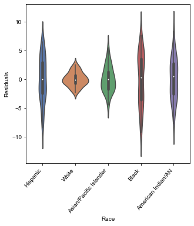

```python
fig, ax = plt.subplots(figsize=(5,5))
sb.set(style = 'whitegrid')
finalDF['Residuals'] = res.resid
sb.violinplot( data = finalDF, x= 'Race', y='Residuals')
plt.xticks(rotation=50, ha='right')
plt.xlabel('Race')
plt.ylabel('Residuals')
finalDF
```

The results are consistent with what the residuals of a linear regression should look like.

- A median close to 0
- Majority participation about the mean
- Small range, with lower participation near extremes
- Unimodal distribution

Our most recent plot did indicate a simultaneous trend between time and poverty, so now we'll complete another linear regression with year as an interaction term with race using ':'.

```python
res2 = smf.ols(formula= "Q(\"Percent Below Poverty\") ~ Race:Year ", data=finalDF).fit()
print(res2.summary())
```

```
                                OLS Regression Results
======================================================================================
Dep. Variable:     Q("Percent Below Poverty")   R-squared:                       0.874
Model:                                    OLS   Adj. R-squared:                  0.872
Method:                         Least Squares   F-statistic:                     325.6
Date:                        Fri, 12 May 2023   Prob (F-statistic):          3.21e-103
Time:                                17:45:02   Log-Likelihood:                -595.28
No. Observations:                         240   AIC:                             1203.
Df Residuals:                             234   BIC:                             1223.
Df Model:                                   5
Covariance Type:                    nonrobust
=====================================================================================================
                                        coef    std err          t      P>|t|      [0.025      0.975]
-----------------------------------------------------------------------------------------------------
Intercept                           253.8624     26.612      9.539      0.000     201.433     306.292
Race[American Indian/AN]:Year        -0.1137      0.013     -8.565      0.000      -0.140      -0.088
Race[Asian/Pacific Islander]:Year    -0.1207      0.013     -9.094      0.000      -0.147      -0.095
Race[Black]:Year                     -0.1131      0.013     -8.485      0.000      -0.139      -0.087
Race[Hispanic]:Year                  -0.1150      0.013     -8.629      0.000      -0.141      -0.089
Race[White]:Year                     -0.1219      0.013     -9.135      0.000      -0.148      -0.096
==============================================================================
Omnibus:                        3.373   Durbin-Watson:                   0.409
Prob(Omnibus):                  0.185   Jarque-Bera (JB):                2.332
Skew:                           0.006   Prob(JB):                        0.312
Kurtosis:                       2.517   Cond. No.                     1.39e+05
==============================================================================

Notes:
[1] Standard Errors assume that the covariance matrix of the errors is correctly specified.
[2] The condition number is large, 1.39e+05. This might indicate that there are
strong multicollinearity or other numerical problems.
```

A p-value that's nearly 0 and a large F-statistic (thats actually larger than our first linear regression) indicate that there is a statistically significant relationship between Poverty, Race, and Year, such that we can reject the null hypothesis. In other words, race and year are statistically significant predictors of poverty.